Atlantic Cod

BOLDGenotyper v1.0.0

# Atlantic Cod

BOLDGenotyper Analysis Report

Generated: 2025-11-19 22:07:07

560

Total Samples

4

Genotypes

97.5%

Assignment Rate

## Analysis Summary

Total Samples

560

Samples analyzed

With Sequence Data

547

97.7% of total

Consensus Groups

4

Unique genotypes identified

Species Identified

1

Distinct species

Successfully Assigned

546

97.5% assignment rate

Mean Identity

94.2%

For assigned samples

Geographic coverage

## Pipeline Parameters

The following parameters were used for this analysis:

| Parameter | Value | Description |
| --- | --- | --- |
| **Clustering Threshold** | `0.02` (98.0% identity) | Maximum genetic distance for grouping sequences into consensus genotypes. Lower values create more groups with tighter genetic similarity. |
| **Similarity Threshold** | `0.5` (50% identity) | Minimum sequence identity required for assigning samples to genotypes. Samples below this threshold are marked as unassigned. |
| **Tie Margin** | `0.003` (0.3% difference) | Maximum identity difference between top matches to flag as ambiguous. Samples with (best - runner-up) < tie margin are flagged for manual review. |
| **Tie Threshold** | `0.95` (95% identity) | Minimum best-match identity required to consider tie detection. Prevents flagging low-quality matches as ties. |
| **Threads** | `4` | Number of parallel processing threads used. |
| **Phylogenetic Tree** | `True` | Whether phylogenetic tree was constructed. |

## Genotype Assignment Results

### Assignment Status Breakdown

| Status | Count | Percentage |
| --- | --- | --- |
| Successfully Assigned | 546 | 97.5% |
| Low Confidence | 0 | 0.0% |
| Tied Assignment | 0 | 0.0% |
| Below Threshold | 1 | 0.2% |
| No Sequence Data | 13 | 2.3% |

### Identity Score Statistics (Assigned Samples)

[output not shown]

## Taxonomy

### Consensus Group Taxonomy

| consensus_group | assigned_sp | assignment_level | assignment_notes | majority_fraction |
| --- | --- | --- | --- | --- |
| consensus_c1_n229 | Gadus morhua | species | majority 1.00 | 1.0 |
| consensus_c2_n304 | Gadus morhua | species | majority 1.00 | 1.0 |
| consensus_c3_n1 | Gadus morhua | species | majority 1.00 | 1.0 |
| consensus_c4_n12 | Gadus morhua | species | majority 1.00 | 1.0 |

### Species Composition by Consensus Group

| consensus_group | reported_species | n | frac | n_in_group |
| --- | --- | --- | --- | --- |
| consensus_c1_n229 | Gadus morhua | 229 | 1.0 | 229.0 |
| consensus_c2_n304 | Gadus morhua | 304 | 1.0 | 304.0 |
| consensus_c3_n1 | Gadus morhua | 1 | 1.0 | 1.0 |
| consensus_c4_n12 | Gadus morhua | 12 | 1.0 | 12.0 |
| NaN | Gadus morhua | 14 | NaN | NaN |

## Geographic Distribution

**Geographic Analysis Summary:** 96 of 560 samples (17.1%) have defined geographic locations. 464 samples (82.9%) with unknown or missing geography were excluded from geographic analyses.

### Sample Distribution by Ocean Basin

| Ocean Basin | Sample Count | Percentage |
| --- | --- | --- |
| North Atlantic Ocean | 81 | 84.4 |
| Arctic Ocean | 15 | 15.6 |

### Genotypes per Ocean Basin

| ocean_basin | consensus_group | Arctic Ocean | North Atlantic Ocean |
| --- | --- | --- | --- |
|  | Unassigned | 3 | 1 |
|  | consensus_c1_n229 | 11 | 79 |
|  | consensus_c2_n304 | 1 | 0 |
|  | consensus_c3_n1 | 0 | 1 |

## Visualizations

### Identity Distribution

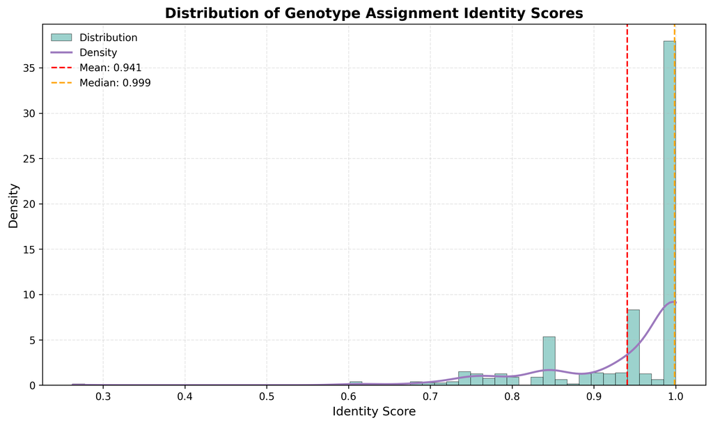

### Phylogenetic Tree

Phylogenetic tree showing relationships between consensus groups

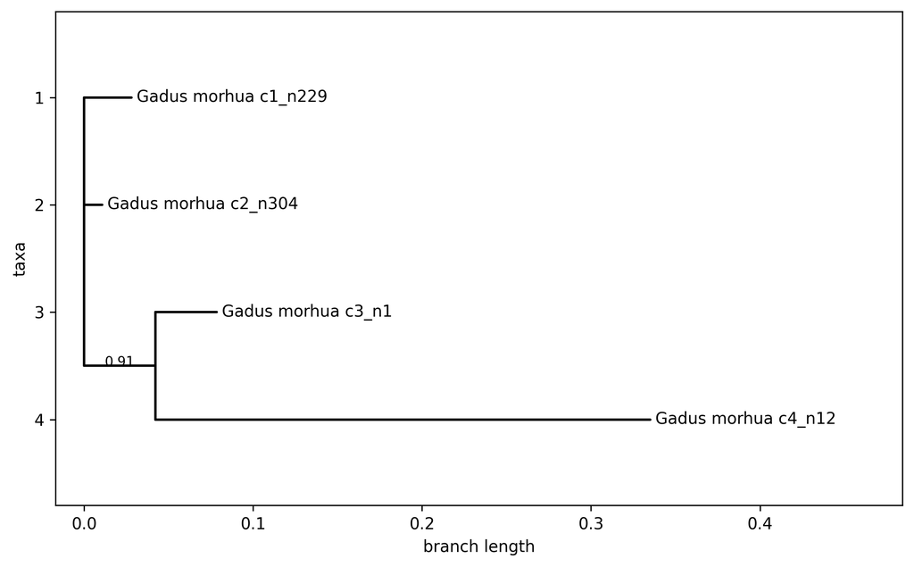

### Relative Abundance by Ocean Basin

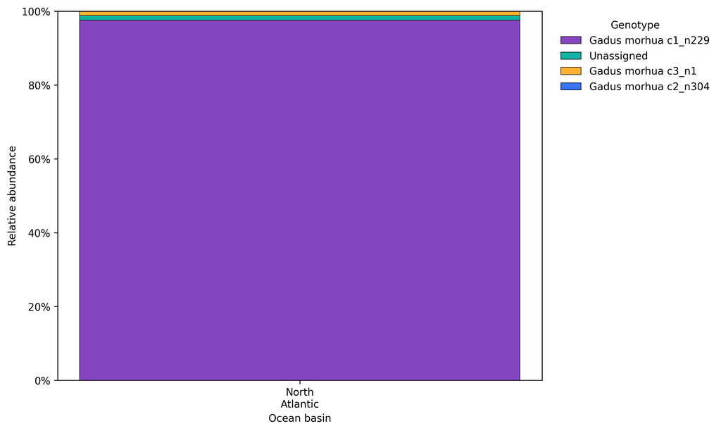

### Total Abundance by Ocean Basin

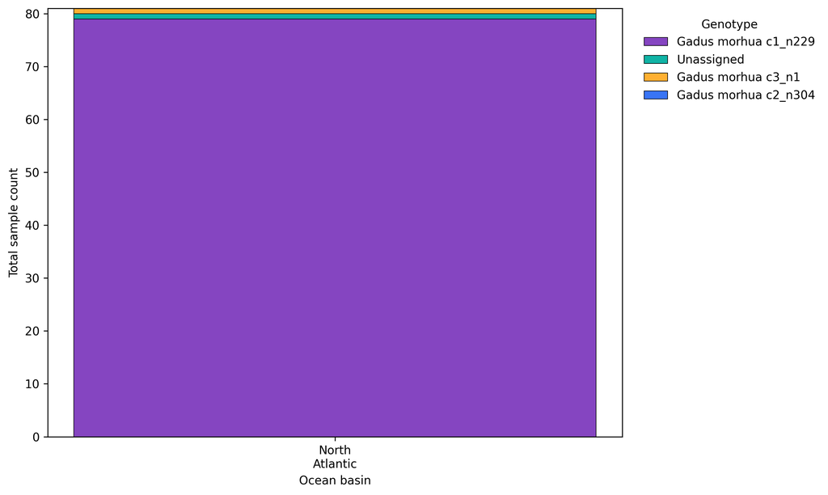

### Total Abundance by Ocean Basin (Faceted)

Total sample counts faceted by species or genotype

[figure not shown]

### Distribution Map

Geographic distribution of samples

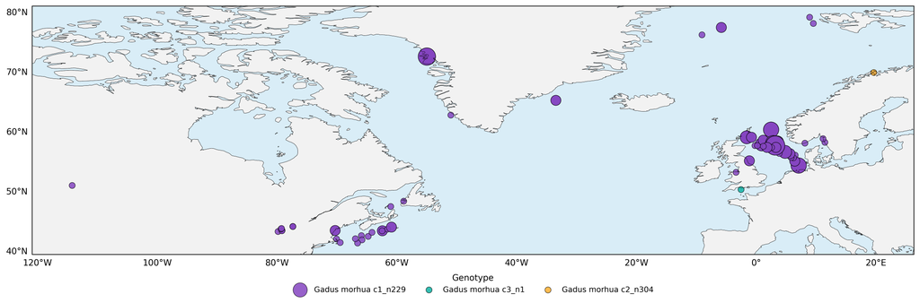

### Distribution Map (Faceted)

Geographic distribution faceted by species or genotype

[figure not shown]

**BOLDGenotyper** - Automated genotyping pipeline for BOLD barcode data  
[GitHub Repository](https://github.com/anthropics/boldgenotyper)

Report generated on 2025-11-19 22:07:07  
For questions or issues, please visit the GitHub repository.